# Chapter 3

John D.

1/12/2021

```r
R.version
```

```
##                _
## platform       x86_64-w64-mingw32
## arch           x86_64
## os             mingw32
## system         x86_64, mingw32
## status
## major          4
## minor          0.2
## year           2020
## month          06
## day            22
## svn rev        78730
## language       R
## version.string R version 4.0.2 (2020-06-22)
## nickname       Taking Off Again
```

```r
library("keras")
library("dplyr")
```

# Chapter 3. Getting started with neural networks

## 3.1. ANATOMY OF A NEURAL NETWORK

### 3.1.1. Layers: the building blocks of deep learning

```r
layer <- layer_dense(units = 32, input_shape = c(784))
layer
```

```
## <tensorflow.python.keras.layers.core.Dense>
```

```r
model <- keras_model_sequential() %>%
  layer_dense(units = 32, input_shape = c(784)) %>%
  layer_dense(units = 32)
model
```

```
## Model
## Model: "sequential"
## ________________________________________________________________________________
## Layer (type)                        Output Shape                    Param #
## ================================================================================
## dense_1 (Dense)                     (None, 32)                      25120
## ________________________________________________________________________________
## dense_2 (Dense)                     (None, 32)                      1056
## ================================================================================
## Total params: 26,176
## Trainable params: 26,176
## Non-trainable params: 0
## ________________________________________________________________________________
```

### 3.1.2. Models: networks of layers

### 3.1.3. Loss functions and optimizers: keys to configuring the learning process

## 3.2. INTRODUCTION TO KERAS

### 3.2.1. Keras, TensorFlow, Theano, and CNTK

### 3.2.2. Installing Keras

### 3.2.3. Developing with Keras: a quick overview

```r
model <- keras_model_sequential() %>%
  layer_dense(units = 32, input_shape = c(784)) %>%
  layer_dense(units = 10, activation = "softmax")
model
```

```
## Model
## Model: "sequential_1"
## ________________________________________________________________________________
## Layer (type)                        Output Shape                    Param #
## ================================================================================
## dense_3 (Dense)                     (None, 32)                      25120
## ________________________________________________________________________________
## dense_4 (Dense)                     (None, 10)                      330
## ================================================================================
## Total params: 25,450
## Trainable params: 25,450
## Non-trainable params: 0
## ________________________________________________________________________________
```

```r
input_tensor <- layer_input(shape = c(784))
input_tensor
```

```
## Tensor("input_1:0", shape=(None, 784), dtype=float32)
```

```r
output_tensor <- input_tensor %>%
  layer_dense(units = 32, activation = "relu") %>%
  layer_dense(units = 10, activation = "softmax")
output_tensor
```

```
## Tensor("dense_6/Identity:0", shape=(None, 10), dtype=float32)
```

```r
model <- keras_model(inputs = input_tensor, outputs = output_tensor)
model
```

```
## Model
## Model: "model"
## ________________________________________________________________________________
## Layer (type)                        Output Shape                    Param #
## ================================================================================
## input_1 (InputLayer)                [(None, 784)]                   0
## ________________________________________________________________________________
## dense_5 (Dense)                     (None, 32)                      25120
## ________________________________________________________________________________
## dense_6 (Dense)                     (None, 10)                      330
## ================================================================================
## Total params: 25,450
## Trainable params: 25,450
## Non-trainable params: 0
## ________________________________________________________________________________
```

```r
model %>% compile(
  optimizer = optimizer_rmsprop(lr = 0.0001),
  loss = "mse",
  metrics = c("accuracy")
)
model
```

```
## Model
## Model: "model"
## ________________________________________________________________________________
## Layer (type)                        Output Shape                    Param #
## ================================================================================
## input_1 (InputLayer)                [(None, 784)]                   0
## ________________________________________________________________________________
## dense_5 (Dense)                     (None, 32)                      25120
## ________________________________________________________________________________
## dense_6 (Dense)                     (None, 10)                      330
## ================================================================================
## Total params: 25,450
## Trainable params: 25,450
## Non-trainable params: 0
## ________________________________________________________________________________
```

```r
# model %>% fit(input_tensor, target_tensor, batch_size = 128, epochs = 10)
# model
```

## 3.3. SETTING UP A DEEP-LEARNING WORKSTATION

### 3.3.1. Getting Keras running: two options

### 3.3.2. Running deep-learning jobs in the cloud: pros and cons

### 3.3.3. What is the best GPU for deep learning?

## 3.4. CLASSIFYING MOVIE REVIEWS: A BINARY CLASSIFICATION EXAMPLE

### 3.4.1. The IMDB dataset

```r
imdb <- dataset_imdb(num_words = 10000)
str(imdb)
```

[output not shown]

[output cut: 152 more lines]

```
##   .. ..$ : int [1:81] 1 73 474 28 8 135 15 13 81 205 ...
##   .. ..$ : int [1:242] 1 13 191 79 14 509 125 61 1224 45 ...
##   .. ..$ : int [1:218] 1 13 188 5158 8 14 2446 31 2 2655 ...
##   .. ..$ : int [1:193] 1 864 13 124 198 1591 623 23 94 2558 ...
##   .. ..$ : int [1:467] 1 1318 133 9 160 87 8894 20 198 33 ...
##   .. ..$ : int [1:74] 1 13 104 14 9 6 87 356 969 22 ...
##   .. ..$ : int [1:76] 1 114 600 229 6 3592 7 6363 116 24 ...
##   .. ..$ : int [1:736] 1 4 3768 356 20 1308 47 1084 4 3241 ...
##   .. ..$ : int [1:448] 1 2 6172 526 34 4 530 2 5893 2 ...
##   .. ..$ : int [1:200] 1 14 9 6 1332 1253 7 4 592 848 ...
##   .. ..$ : int [1:185] 1 13 296 14 20 260 115 332 4 274 ...
##   .. ..$ : int [1:124] 1 2787 7056 59 93 14 20 18 72 207 ...
##   .. ..$ : int [1:122] 1 216 23 150 89 122 32 7 134 1020 ...
##   .. .. [list output truncated]
##   ..$ y: int [1:25000] 0 1 1 0 1 1 1 0 0 1 ...
```

```r
c(c(train_data, train_labels), c(test_data, test_labels)) %<-% imdb # Takes imdb, a list of 2 lists (train and test) (x and y) and assigns them
```

```r
`%<-%`
```

```
## function (x, value)
## {
##     tryCatch(multi_assign(substitute(x), value, parent.frame()),
##         invalid_lhs = function(e) {
##             stop("invalid `%<-%` left-hand side, ", e$message,
##                 call. = FALSE)
##         }, invalid_rhs = function(e) {
##             stop("invalid `%<-%` right-hand side, ", e$message,
##                 call. = FALSE)
##         })
## }
## <bytecode: 0x00000000628980d0>
## <environment: namespace:zeallot>
```

```r
#imdb <- dataset_imdb(num_words = 10000)
#train_data <- imdb$train$x
#train_labels <- imdb$train$y
#test_data <- imdb$test$x
#test_labels <- imdb$test$y
```

```r
str(train_data[[1]])
```

```
##  int [1:218] 1 14 22 16 43 530 973 1622 1385 65 ...
```

```r
train_labels[[1]]
```

```
## [1] 1
```

```r
max(sapply(train_data, max))
```

```
## [1] 9999
```

```r
word_index <- dataset_imdb_word_index()
head(word_index)
```

```
## $fawn
## [1] 34701
##
## $tsukino
## [1] 52006
##
## $nunnery
## [1] 52007
##
## $sonja
## [1] 16816
##
## $vani
## [1] 63951
##
## $woods
## [1] 1408
```

```r
reverse_word_index <- names(word_index)
head(reverse_word_index)
```

```
## [1] "fawn"    "tsukino" "nunnery" "sonja"   "vani"    "woods"
```

```r
names(reverse_word_index) <- word_index
head(reverse_word_index)
```

```
##     34701     52006     52007     16816     63951      1408
##    "fawn" "tsukino" "nunnery"   "sonja"    "vani"   "woods"
```

```r
decoded_review <- sapply(train_data[[1]], function(index) {
  word <- if (index >= 3) reverse_word_index[[as.character(index - 3)]]
  if (!is.null(word)) word else "?"
})
head(decoded_review)
```

```
## [1] "?"         "this"      "film"      "was"       "just"      "brilliant"
```

### 3.4.2. Preparing the data

```r
vectorize_sequences <- function(sequences, dimension = 10000) {
  results <- matrix(0, nrow = length(sequences), ncol = dimension)
  for (i in 1:length(sequences))
    results[i, sequences[[i]]] <- 1
  results
}

x_train <- vectorize_sequences(train_data)
x_test <- vectorize_sequences(test_data)
```

```r
dim(x_train)
```

```
## [1] 25000 10000
```

```r
train_data[[1]]
```

```
##   [1]    1   14   22   16   43  530  973 1622 1385   65  458 4468   66 3941    4
##  [16]  173   36  256    5   25  100   43  838  112   50  670    2    9   35  480
##  [31]  284    5  150    4  172  112  167    2  336  385   39    4  172 4536 1111
##  [46]   17  546   38   13  447    4  192   50   16    6  147 2025   19   14   22
##  [61]    4 1920 4613  469    4   22   71   87   12   16   43  530   38   76   15
##  [76]   13 1247    4   22   17  515   17   12   16  626   18    2    5   62  386
##  [91]   12    8  316    8  106    5    4 2223 5244   16  480   66 3785   33    4
## [106]  130   12   16   38  619    5   25  124   51   36  135   48   25 1415   33
## [121]    6   22   12  215   28   77   52    5   14  407   16   82    2    8    4
## [136]  107  117 5952   15  256    4    2    7 3766    5  723   36   71   43  530
## [151]  476   26  400  317   46    7    4    2 1029   13  104   88    4  381   15
## [166]  297   98   32 2071   56   26  141    6  194 7486   18    4  226   22   21
## [181]  134  476   26  480    5  144   30 5535   18   51   36   28  224   92   25
## [196]  104    4  226   65   16   38 1334   88   12   16  283    5   16 4472  113
## [211]  103   32   15   16 5345   19  178   32
```

```r
x_train[1,1:10]
```

```
##  [1] 1 1 0 1 1 1 1 1 1 0
```

The vector is all 10,000 words we are using. A 1 means it is present in the review and a 0 means it is absent in the review. This message does not take into account the frequency or order of the words used in the review

```r
str(x_train[1,])
```

```
##  num [1:10000] 1 1 0 1 1 1 1 1 1 0 ...
```

```r
y_train <- as.numeric(train_labels)
y_test <- as.numeric(test_labels)
```

### 3.4.3. Building your network

```r
# output = relu(dot(W, input) + b)
```

```r
model <- keras_model_sequential() %>%
  layer_dense(units = 16, activation = "relu", input_shape = c(10000)) %>%
  layer_dense(units = 16, activation = "relu") %>%
  layer_dense(units = 1, activation = "sigmoid")
model
```

```
## Model
## Model: "sequential_2"
## ________________________________________________________________________________
## Layer (type)                        Output Shape                    Param #
## ================================================================================
## dense_7 (Dense)                     (None, 16)                      160016
## ________________________________________________________________________________
## dense_8 (Dense)                     (None, 16)                      272
## ________________________________________________________________________________
## dense_9 (Dense)                     (None, 1)                       17
## ================================================================================
## Total params: 160,305
## Trainable params: 160,305
## Non-trainable params: 0
## ________________________________________________________________________________
```

```r
model %>% compile(
  optimizer = "rmsprop",
  loss = "binary_crossentropy",
  metrics = c("accuracy")
)
model
```

```
## Model
## Model: "sequential_2"
## ________________________________________________________________________________
## Layer (type)                        Output Shape                    Param #
## ================================================================================
## dense_7 (Dense)                     (None, 16)                      160016
## ________________________________________________________________________________
## dense_8 (Dense)                     (None, 16)                      272
## ________________________________________________________________________________
## dense_9 (Dense)                     (None, 1)                       17
## ================================================================================
## Total params: 160,305
## Trainable params: 160,305
## Non-trainable params: 0
## ________________________________________________________________________________
```

```r
#model %>% compile(
#  optimizer = optimizer_rmsprop(lr=0.001),
#  loss = "binary_crossentropy",
#  metrics = c("accuracy")
#)
```

```r
#model %>% compile(
#  optimizer = optimizer_rmsprop(lr = 0.001),
#  loss = loss_binary_crossentropy,
#  metrics = metric_binary_accuracy
#)
```

### 3.4.4. Validating your approach

```r
val_indices <- 1:10000

x_val <- x_train[val_indices,]
partial_x_train <- x_train[-val_indices,]
y_val <- y_train[val_indices]
partial_y_train <- y_train[-val_indices]
```

```r
model %>% compile(
  optimizer = "rmsprop",
  loss = "binary_crossentropy",
  metrics = c("accuracy")
)

history <- model %>% fit(
  partial_x_train,
  partial_y_train,
  epochs = 20,
  batch_size = 512,
  validation_data = list(x_val, y_val)
)
```

```r
str(history)
```

```
## List of 2
##  $ params :List of 3
##   ..$ verbose: int 1
##   ..$ epochs : int 20
##   ..$ steps  : int 30
##  $ metrics:List of 4
##   ..$ loss        : num [1:20] 0.528 0.327 0.239 0.186 0.155 ...
##   ..$ accuracy    : num [1:20] 0.792 0.901 0.926 0.941 0.949 ...
##   ..$ val_loss    : num [1:20] 0.44 0.324 0.298 0.274 0.277 ...
##   ..$ val_accuracy: num [1:20] 0.814 0.881 0.881 0.891 0.889 ...
##  - attr(*, "class")= chr "keras_training_history"
```

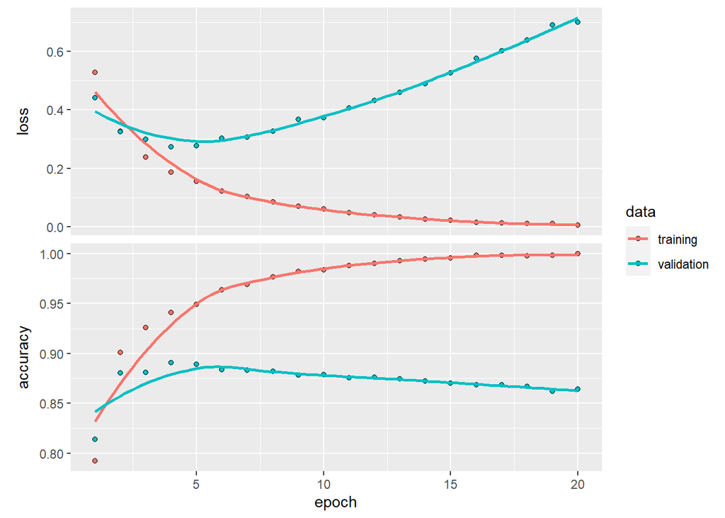

```r
plot(history)
```

```r
history_df <- as.data.frame(history)
str(history_df)
```

```
## 'data.frame':    80 obs. of  4 variables:
##  $ epoch : int  1 2 3 4 5 6 7 8 9 10 ...
##  $ value : num  0.528 0.327 0.239 0.186 0.155 ...
##  $ metric: Factor w/ 2 levels "loss","accuracy": 1 1 1 1 1 1 1 1 1 1 ...
##  $ data  : Factor w/ 2 levels "training","validation": 1 1 1 1 1 1 1 1 1 1 ...
```

```r
model <- keras_model_sequential() %>%
  layer_dense(units = 16, activation = "relu", input_shape = c(10000)) %>%
  layer_dense(units = 16, activation = "relu") %>%
  layer_dense(units = 1, activation = "sigmoid")

model %>% compile(
  optimizer = "rmsprop",
  loss = "binary_crossentropy",
  metrics = c("accuracy")
)

model %>% fit(x_train, y_train, epochs = 4, batch_size = 512)
results <- model %>% evaluate(x_test, y_test)
```

```r
results
```

```
##      loss  accuracy
## 0.3037123 0.8780800
```

### 3.4.5. Using a trained network to generate predictions on new data

```r
model %>% predict(x_test[1:10,])
```

```
##              [,1]
##  [1,] 0.153961718
##  [2,] 0.997967124
##  [3,] 0.731614172
##  [4,] 0.617387891
##  [5,] 0.925010562
##  [6,] 0.700834692
##  [7,] 0.997455299
##  [8,] 0.006846994
##  [9,] 0.936044514
## [10,] 0.975701332
```

### 3.4.6. Further experiments

### 3.4.7. Wrapping up

## 3.4.6 Problems

### 1. You used two hidden layers. Try using one or three hidden layers, and see how doing so affects validation and test accuracy.

```r
# clear space
ls()
```

```
##  [1] "decoded_review"      "history"             "history_df"
##  [4] "imdb"                "input_tensor"        "layer"
##  [7] "model"               "output_tensor"       "partial_x_train"
## [10] "partial_y_train"     "results"             "reverse_word_index"
## [13] "test_data"           "test_labels"         "train_data"
## [16] "train_labels"        "val_indices"         "vectorize_sequences"
## [19] "word_index"          "x_test"              "x_train"
## [22] "x_val"               "y_test"              "y_train"
## [25] "y_val"
```

```r
rm(decoded_review, history, history_df, imdb, input_tensor, layer, model, output_tensor,
  partial_x_train, partial_y_train, results, reverse_word_index, test_data, test_labels, train_data, train_labels, val_indices,
  vectorize_sequences, word_index, x_val, y_val)
gc()
```

```
##             used   (Mb) gc trigger   (Mb)  max used   (Mb)
## Ncells   2052252  109.7    4041962  215.9   4041962  215.9
## Vcells 503801039 3843.7  913774680 6971.6 762469707 5817.2
```

```r
ls()
```

```
## [1] "x_test"  "x_train" "y_test"  "y_train"
```

```r
# 1 hidden layer
model <- keras_model_sequential() %>%
  layer_dense(units = 16, activation = "relu", input_shape = c(10000)) %>%
  layer_dense(units = 1, activation = "sigmoid")

model %>% compile(
  optimizer = "rmsprop",
  loss = "binary_crossentropy",
  metrics = c("accuracy")
)

model %>% fit(x_train, y_train, epochs = 4, batch_size = 512)
results <- model %>% evaluate(x_test, y_test)
results
```

```
##      loss  accuracy
## 0.2829302 0.8869600
```

```r
gc()
```

```
##             used   (Mb) gc trigger   (Mb)  max used   (Mb)
## Ncells   2052271  109.7    4041962  215.9   4041962  215.9
## Vcells 503701211 3843.0  913774680 6971.6 762469707 5817.2
```

```r
# 3 hidden layers
model <- keras_model_sequential() %>%
  layer_dense(units = 16, activation = "relu", input_shape = c(10000)) %>%
  layer_dense(units = 16, activation = "relu") %>%
  layer_dense(units = 16, activation = "relu") %>%
  layer_dense(units = 1, activation = "sigmoid")

model %>% compile(
  optimizer = "rmsprop",
  loss = "binary_crossentropy",
  metrics = c("accuracy")
)

model %>% fit(x_train, y_train, epochs = 4, batch_size = 512)
results <- model %>% evaluate(x_test, y_test)
results
```

```
##      loss  accuracy
## 0.3114998 0.8791200
```

```r
gc()
```

```
##             used   (Mb) gc trigger   (Mb)  max used   (Mb)
## Ncells   2052478  109.7    4041962  215.9   4041962  215.9
## Vcells 503701651 3843.0  913774680 6971.6 762469707 5817.2
```

### 2. Try using layers with more hidden units or fewer hidden units: 32 units, 64 units, and so on.2

```r
# 8 Hidden Units
model <- keras_model_sequential() %>%
  layer_dense(units = 8, activation = "relu", input_shape = c(10000)) %>%
  layer_dense(units = 8, activation = "relu") %>%
  layer_dense(units = 1, activation = "sigmoid")

model %>% compile(
  optimizer = "rmsprop",
  loss = "binary_crossentropy",
  metrics = c("accuracy")
)

model %>% fit(x_train, y_train, epochs = 4, batch_size = 512)
results <- model %>% evaluate(x_test, y_test)
results
```

```
##      loss  accuracy
## 0.2799966 0.8898800
```

```r
gc()
```

```
##             used   (Mb) gc trigger   (Mb)  max used   (Mb)
## Ncells   2052574  109.7    4041962  215.9   4041962  215.9
## Vcells 503701643 3843.0  913774680 6971.6 762469707 5817.2
```

```r
# 32 Hidden Units
model <- keras_model_sequential() %>%
  layer_dense(units = 32, activation = "relu", input_shape = c(10000)) %>%
  layer_dense(units = 32, activation = "relu") %>%
  layer_dense(units = 1, activation = "sigmoid")

model %>% compile(
  optimizer = "rmsprop",
  loss = "binary_crossentropy",
  metrics = c("accuracy")
)

model %>% fit(x_train, y_train, epochs = 4, batch_size = 512)
results <- model %>% evaluate(x_test, y_test)
results
```

```
##      loss  accuracy
## 0.3111375 0.8797200
```

```r
gc()
```

```
##             used   (Mb) gc trigger   (Mb)  max used   (Mb)
## Ncells   2052708  109.7    4041962  215.9   4041962  215.9
## Vcells 503701784 3843.0  913774680 6971.6 762469707 5817.2
```

```r
# 64 Hidden Units
model <- keras_model_sequential() %>%
  layer_dense(units = 64, activation = "relu", input_shape = c(10000)) %>%
  layer_dense(units = 64, activation = "relu") %>%
  layer_dense(units = 1, activation = "sigmoid")

model %>% compile(
  optimizer = "rmsprop",
  loss = "binary_crossentropy",
  metrics = c("accuracy")
)

model %>% fit(x_train, y_train, epochs = 4, batch_size = 512)
results <- model %>% evaluate(x_test, y_test)
results
```

```
##      loss  accuracy
## 0.3831085 0.8571600
```

```r
gc()
```

```
##             used   (Mb) gc trigger   (Mb)  max used   (Mb)
## Ncells   2052842  109.7    4041962  215.9   4041962  215.9
## Vcells 503701926 3843.0  913774680 6971.6 762469707 5817.2
```

### 3. Try using the mse loss function instead of binary_crossentropy

```r
model <- keras_model_sequential() %>%
  layer_dense(units = 16, activation = "relu", input_shape = c(10000)) %>%
  layer_dense(units = 16, activation = "relu") %>%
  layer_dense(units = 1, activation = "sigmoid")

model %>% compile(
  optimizer = "rmsprop",
  loss = "mse",
  metrics = c("accuracy")
)

model %>% fit(x_train, y_train, epochs = 4, batch_size = 512)
results <- model %>% evaluate(x_test, y_test)
results
```

```
##       loss   accuracy
## 0.08625448 0.88367999
```

```r
gc()
```

```
##             used   (Mb) gc trigger   (Mb)  max used   (Mb)
## Ncells   2052057  109.6    4041962  215.9   4041962  215.9
## Vcells 503701633 3843.0  913774680 6971.6 762469707 5817.2
```

### 4. Try using the tanh activation (an activation that was popular in the early days of neural networks) instead of relu.

```r
model <- keras_model_sequential() %>%
  layer_dense(units = 16, activation = "tanh", input_shape = c(10000)) %>%
  layer_dense(units = 16, activation = "tanh") %>%
  layer_dense(units = 1, activation = "sigmoid")

model %>% compile(
  optimizer = "rmsprop",
  loss = "binary_crossentropy",
  metrics = c("accuracy")
)

model %>% fit(x_train, y_train, epochs = 4, batch_size = 512)
results <- model %>% evaluate(x_test, y_test)
results
```

```
##      loss  accuracy
## 0.3570932 0.8648800
```

```r
gc()
```

```
##             used   (Mb) gc trigger   (Mb)  max used   (Mb)
## Ncells   2052039  109.6    4041962  215.9   4041962  215.9
## Vcells 503701696 3843.0  913774680 6971.6 762469707 5817.2
```

Using tanh for activation led to a decrease in accuracy

## 3.5. CLASSIFYING NEWSWIRES: A MULTICLASS CLASSIFICATION EXAMPLE

```r
rm(x_test,x_train,y_test,y_train)
gc()
```

```
##             used   (Mb) gc trigger   (Mb)  max used   (Mb)
## Ncells   2051166  109.6    4041962  215.9   4041962  215.9
## Vcells 253624674 1935.1  731019744 5577.3 762469707 5817.2
```

### 3.5.1. The Reuters dataset

```r
reuters <- dataset_reuters(num_words = 10000)
c(c(train_data, train_labels), c(test_data, test_labels)) %<-% reuters
```

```r
length(train_data)
```

```
## [1] 8982
```

```r
length(test_data)
```

```
## [1] 2246
```

```r
train_data[[1]]
```

```
##  [1]    1    2    2    8   43   10  447    5   25  207  270    5 3095  111   16
## [16]  369  186   90   67    7   89    5   19  102    6   19  124   15   90   67
## [31]   84   22  482   26    7   48    4   49    8  864   39  209  154    6  151
## [46]    6   83   11   15   22  155   11   15    7   48    9 4579 1005  504    6
## [61]  258    6  272   11   15   22  134   44   11   15   16    8  197 1245   90
## [76]   67   52   29  209   30   32  132    6  109   15   17   12
```

```r
word_index <- dataset_reuters_word_index()
reverse_word_index <- names(word_index)
names(reverse_word_index) <- word_index
decoded_newswire <- sapply(train_data[[1]], function(index) {
  word <- if (index >= 3) reverse_word_index[[as.character(index - 3)]]
  if (!is.null(word)) word else "?"
})
```

```r
train_labels[[1]]
```

```
## [1] 3
```

### 3.5.2. Preparing the data

```r
vectorize_sequences <- function(sequences, dimension = 10000) {
  results <- matrix(0, nrow = length(sequences), ncol = dimension)
  for (i in 1:length(sequences))
    results[i, sequences[[i]]] <- 1
  results
}

x_train <- vectorize_sequences(train_data)
x_test <- vectorize_sequences(test_data)
```

```r
to_one_hot <- function(labels, dimension = 46) {
  results <- matrix(0, nrow = length(labels), ncol = dimension)
  for (i in 1:length(labels))
    results[i, labels[[i]] + 1] <- 1
  results
}

one_hot_train_labels <- to_one_hot(train_labels)
one_hot_test_labels <- to_one_hot(test_labels)
```

```r
one_hot_train_labels <- to_categorical(train_labels)
one_hot_test_labels <- to_categorical(test_labels)
```

### 3.5.3. Building your network

```r
model <- keras_model_sequential() %>%
  layer_dense(units = 64, activation = "relu", input_shape = c(10000)) %>%
  layer_dense(units = 64, activation = "relu") %>%
  layer_dense(units = 46, activation = "softmax")
```

```r
model %>% compile(
  optimizer = "rmsprop",
  loss = "categorical_crossentropy",
  metrics = c("accuracy")
)
```

### 3.5.4. Validating your approach

```r
val_indices <- 1:1000

x_val <- x_train[val_indices,]
partial_x_train <- x_train[-val_indices,]

y_val <- one_hot_train_labels[val_indices,]
partial_y_train = one_hot_train_labels[-val_indices,]
```

```r
history <- model %>% fit(
  partial_x_train,
  partial_y_train,
  epochs = 20,
  batch_size = 512,
  validation_data = list(x_val, y_val)
)
```

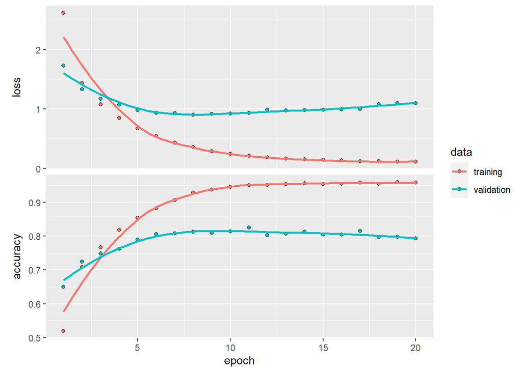

```r
plot(history)
```

```r
model <- keras_model_sequential() %>%
  layer_dense(units = 64, activation = "relu", input_shape = c(10000)) %>%
  layer_dense(units = 64, activation = "relu") %>%
  layer_dense(units = 46, activation = "softmax")

model %>% compile(
  optimizer = "rmsprop",
  loss = "categorical_crossentropy",
  metrics = c("accuracy")
)

history <- model %>% fit(
  partial_x_train,
  partial_y_train,
  epochs = 9,
  batch_size = 512,
  validation_data = list(x_val, y_val)
)

results <- model %>% evaluate(x_test, one_hot_test_labels)
```

```r
results
```

```
##      loss  accuracy
## 0.9887182 0.7862867
```

```r
test_labels_copy <- test_labels
test_labels_copy <- sample(test_labels_copy)
length(which(test_labels == test_labels_copy)) / length(test_labels)
```

```
## [1] 0.1852182
```

### 3.5.5. Generating predictions on new data

```r
predictions <- model %>% predict(x_test)
```

```r
dim(predictions)
```

```
## [1] 2246   46
```

```r
sum(predictions[1,])
```

```
## [1] 1
```

```r
which.max(predictions[1,])
```

```
## [1] 5
```

### 3.5.6. A different way to handle the labels and the loss

```r
model %>% compile(
  optimizer = "rmsprop",
  loss = "sparse_categorical_crossentropy",
  metrics = c("accuracy")
)
```

### 3.5.7. The importance of having sufficiently large intermediate layers

```r
model <- keras_model_sequential() %>%
  layer_dense(units = 64, activation = "relu", input_shape = c(10000)) %>%
  layer_dense(units = 4, activation = "relu") %>%
  layer_dense(units = 46, activation = "softmax")

model %>% compile(
  optimizer = "rmsprop",
  loss = "categorical_crossentropy",
  metrics = c("accuracy")
)

model %>% fit(
  partial_x_train,
  partial_y_train,
  epochs = 20,
  batch_size = 128,
  validation_data = list(x_val, y_val)
)
```

```r
results <- model %>% evaluate(x_test, one_hot_test_labels)
results
```

```
##      loss  accuracy
## 2.2388177 0.6865539
```

### 3.5.8. Further experiments

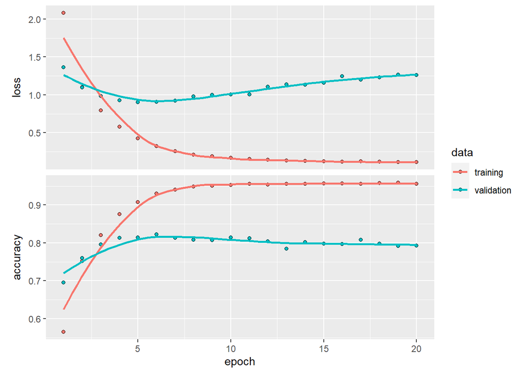

```r
## 32 units
model <- keras_model_sequential() %>%
  layer_dense(units = 64, activation = "relu", input_shape = c(10000)) %>%
  layer_dense(units = 32, activation = "relu") %>%
  layer_dense(units = 46, activation = "softmax")

model %>% compile(
  optimizer = "rmsprop",
  loss = "categorical_crossentropy",
  metrics = c("accuracy")
)

history <-  model %>% fit(
  partial_x_train,
  partial_y_train,
  epochs = 20,
  batch_size = 128,
  validation_data = list(x_val, y_val)
)

plot(history)
```

```r
results <- model %>% evaluate(x_test, one_hot_test_labels)
results
```

```
##      loss  accuracy
## 1.5166950 0.7742653
```

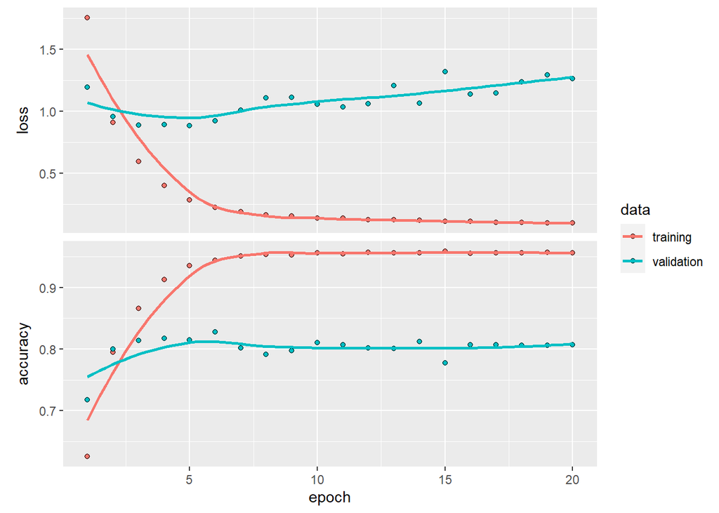

```r
## 128 units
model <- keras_model_sequential() %>%
  layer_dense(units = 64, activation = "relu", input_shape = c(10000)) %>%
  layer_dense(units = 128, activation = "relu") %>%
  layer_dense(units = 46, activation = "softmax")

model %>% compile(
  optimizer = "rmsprop",
  loss = "categorical_crossentropy",
  metrics = c("accuracy")
)

history <-  model %>% fit(
  partial_x_train,
  partial_y_train,
  epochs = 20,
  batch_size = 128,
  validation_data = list(x_val, y_val)
)

plot(history)
```

```r
results <- model %>% evaluate(x_test, one_hot_test_labels)
results
```

```
##      loss  accuracy
## 1.6061522 0.7787177
```

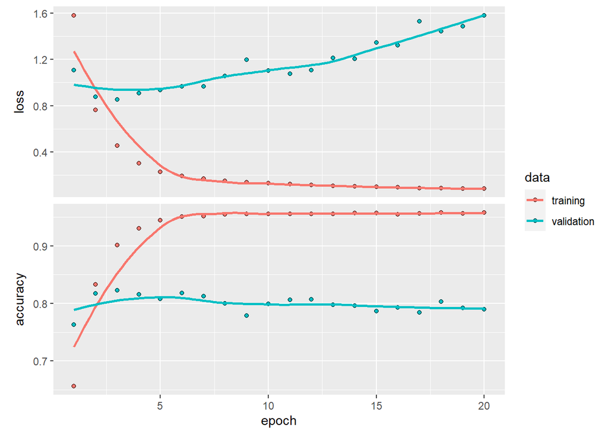

```r
## 128 units twice
model <- keras_model_sequential() %>%
  layer_dense(units = 128, activation = "relu", input_shape = c(10000)) %>%
  layer_dense(units = 128, activation = "relu") %>%
  layer_dense(units = 46, activation = "softmax")

model %>% compile(
  optimizer = "rmsprop",
  loss = "categorical_crossentropy",
  metrics = c("accuracy")
)

history <-  model %>% fit(
  partial_x_train,
  partial_y_train,
  epochs = 20,
  batch_size = 128,
  validation_data = list(x_val, y_val)
)

plot(history)
```

```r
results <- model %>% evaluate(x_test, one_hot_test_labels)
results
```

```
##      loss  accuracy
## 1.9122009 0.7796082
```

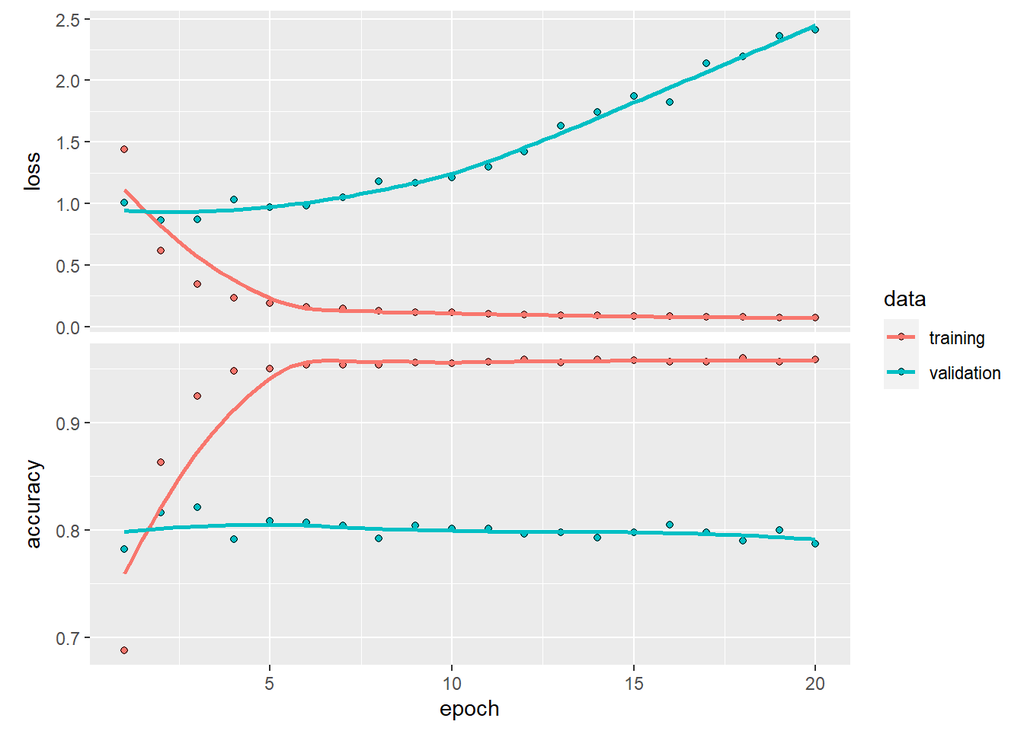

```r
## 256 units twice
model <- keras_model_sequential() %>%
  layer_dense(units = 256, activation = "relu", input_shape = c(10000)) %>%
  layer_dense(units = 256, activation = "relu") %>%
  layer_dense(units = 46, activation = "softmax")

model %>% compile(
  optimizer = "rmsprop",
  loss = "categorical_crossentropy",
  metrics = c("accuracy")
)

history <-  model %>% fit(
  partial_x_train,
  partial_y_train,
  epochs = 20,
  batch_size = 128,
  validation_data = list(x_val, y_val)
)

plot(history)
```

```r
results <- model %>% evaluate(x_test, one_hot_test_labels)
results
```

```
##      loss  accuracy
## 2.8364029 0.7760463
```

Adding more hidden units starts to level out, but too few it gets worse. Overall original example was best

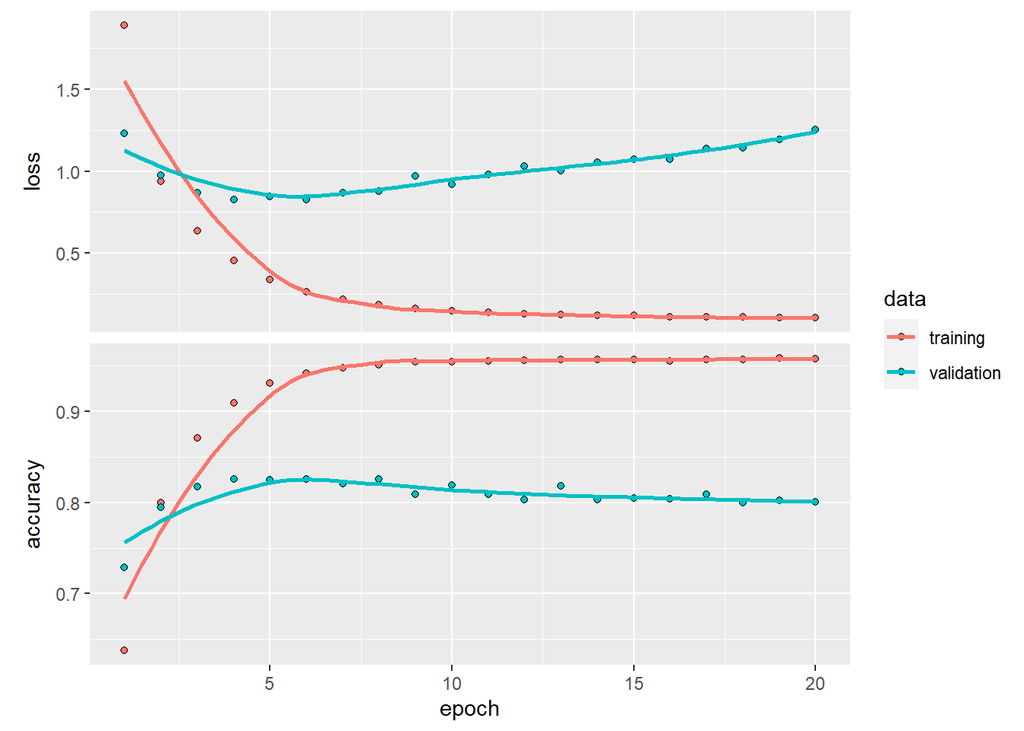

```r
## 1 layer
model <- keras_model_sequential() %>%
  layer_dense(units = 64, activation = "relu", input_shape = c(10000)) %>%
  layer_dense(units = 46, activation = "softmax")

model %>% compile(
  optimizer = "rmsprop",
  loss = "categorical_crossentropy",
  metrics = c("accuracy")
)

history <-  model %>% fit(
  partial_x_train,
  partial_y_train,
  epochs = 20,
  batch_size = 128,
  validation_data = list(x_val, y_val)
)

plot(history)
```

```r
results <- model %>% evaluate(x_test, one_hot_test_labels)
results
```

```
##      loss  accuracy
## 1.4426892 0.7791629
```

1 Layer saw a reduction in accuracy

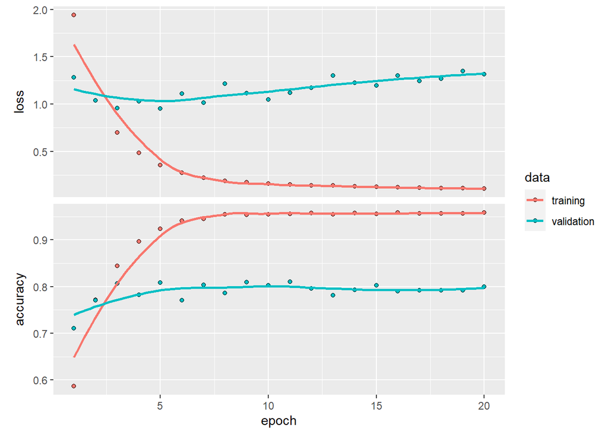

```r
## 3 layers
model <- keras_model_sequential() %>%
  layer_dense(units = 64, activation = "relu", input_shape = c(10000)) %>%
  layer_dense(units = 64, activation = "relu") %>%
  layer_dense(units = 64, activation = "relu") %>%
  layer_dense(units = 46, activation = "softmax")

model %>% compile(
  optimizer = "rmsprop",
  loss = "categorical_crossentropy",
  metrics = c("accuracy")
)

history <-  model %>% fit(
  partial_x_train,
  partial_y_train,
  epochs = 20,
  batch_size = 128,
  validation_data = list(x_val, y_val)
)

plot(history)
```

```r
results <- model %>% evaluate(x_test, one_hot_test_labels)
results
```

```
##      loss  accuracy
## 1.6167985 0.7831701
```

3 layers also reduction in accuracy

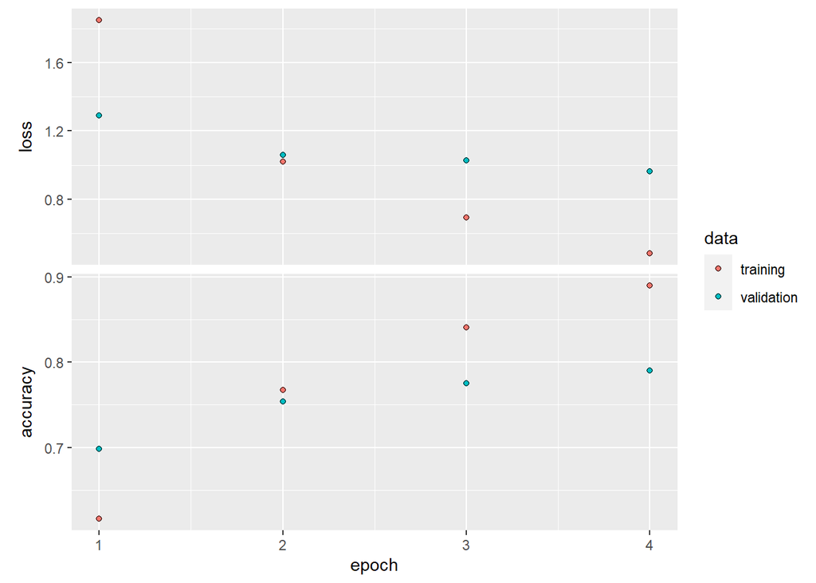

```r
## 3 layers with 4 epochs
model <- keras_model_sequential() %>%
  layer_dense(units = 64, activation = "relu", input_shape = c(10000)) %>%
  layer_dense(units = 64, activation = "relu") %>%
  layer_dense(units = 64, activation = "relu") %>%
  layer_dense(units = 46, activation = "softmax")

model %>% compile(
  optimizer = "rmsprop",
  loss = "categorical_crossentropy",
  metrics = c("accuracy")
)

history <-  model %>% fit(
  partial_x_train,
  partial_y_train,
  epochs = 4,
  batch_size = 128,
  validation_data = list(x_val, y_val)
)

plot(history)
```

```r
results <- model %>% evaluate(x_test, one_hot_test_labels)
results
```

```
##      loss  accuracy
## 1.0340606 0.7818344
```

Same result with less epochs

### 3.5.9. Wrapping up

## 3.6. PREDICTING HOUSE PRICES: A REGRESSION EXAMPLE

### 3.6.1. The Boston Housing Price dataset

```r
dataset <- dataset_boston_housing()
c(c(train_data, train_targets), c(test_data, test_targets)) %<-% dataset
```

```r
str(train_data)
```

```
##  num [1:404, 1:13] 1.2325 0.0218 4.8982 0.0396 3.6931 ...
```

```r
str(test_data)
```

```
##  num [1:102, 1:13] 18.0846 0.1233 0.055 1.2735 0.0715 ...
```

```r
str(train_targets)
```

```
##  num [1:404(1d)] 15.2 42.3 50 21.1 17.7 18.5 11.3 15.6 15.6 14.4 ...
```

### 3.6.2. Preparing the data

```r
mean <- apply(train_data, 2, mean)
std <- apply(train_data, 2, sd)
train_data <- scale(train_data, center = mean, scale = std)
test_data <- scale(test_data, center = mean, scale = std)
```

### 3.6.3. Building your network

```r
build_model <- function() {
  model <- keras_model_sequential() %>%
    layer_dense(units = 64, activation = "relu",
                input_shape = dim(train_data)[[2]]) %>%
    layer_dense(units = 64, activation = "relu") %>%
    layer_dense(units = 1)
  model %>% compile(
    optimizer = "rmsprop",
    loss = "mse",
    metrics = c("mae")
  )
}
```

### 3.6.4. Validating your approach using K-fold validation

```r
# k <- 4
# indices <- sample(1:nrow(train_data))
# folds <- cut(indices, breaks = k, labels = FALSE)
#
# num_epochs <- 100
# all_scores <- c()
# for (i in 1:k) {
#   cat("processing fold #", i, "\n")
#
#   val_indices <- which(folds == i, arr.ind = TRUE)
#   val_data <- train_data[val_indices,]
#   val_targets <- train_targets[val_indices]
#   partial_train_data <- train_data[-val_indices,]
#   partial_train_targets <- train_targets[-val_indices]
#
#   model <- build_model()
#
#   model %>% fit(partial_train_data, partial_train_targets,
#                 epochs = num_epochs, batch_size = 1, verbose = 0)
#
#   results <- model %>% evaluate(val_data, val_targets, verbose = 0)
#   all_scores <- c(all_scores, results[[2]])
# }
```

```r
# all_scores
# mean(all_scores)
```

```r
# num_epochs <- 500
# all_mae_histories <- NULL
# for (i in 1:k) {
#   cat("processing fold #", i, "\n")
#
#   val_indices <- which(folds == i, arr.ind = TRUE)
#   val_data <- train_data[val_indices,]
#   val_targets <- train_targets[val_indices]
#
#   partial_train_data <- train_data[-val_indices,]
#   partial_train_targets <- train_targets[-val_indices]
#
#   model <- build_model()
#
#   history <- model %>% fit(
#     partial_train_data, partial_train_targets,
#     validation_data = list(val_data, val_targets),
#     epochs = num_epochs, batch_size = 1, verbose = 0
#   )
#   mae_history <- history$metrics$val_mean_absolute_error
#   all_mae_histories <- rbind(all_mae_histories, mae_history)
# }
```

```r
# average_mae_history <- data.frame(
#   epoch = seq(1:ncol(all_mae_histories)),
#   validation_mae = apply(all_mae_histories, 2, mean)
# )
```

```r
# library(ggplot2)
# ggplot(average_mae_history, aes(x = epoch, y = validation_mae)) + geom_line()
```

```r
# ggplot(average_mae_history, aes(x = epoch, y = validation_mae)) + geom_smooth()
```

```r
model <- build_model()
model %>% fit(train_data, train_targets,
          epochs = 80, batch_size = 16, verbose = 0)
result <- model %>% evaluate(test_data, test_targets)
```

```r
result
```

```
##      loss       mae
## 18.103470  2.577626
```

### 3.6.5. Wrapping up

## 3.7. SUMMARY

# Problems for 1/12/2021

See if you can fit a model to predict OJ purchase, using the dataset from chapter 8 of the ISLR book (this is used in problem 9 of Chapter 8, which we did in November). How do your results compare to the tree-based methods from ISLR? (be sure to use the same training and test sets)

```r
# Refresh workspace
rm(list = ls())
gc()
```

```
##           used  (Mb) gc trigger   (Mb)  max used   (Mb)
## Ncells 2054745 109.8    4041962  215.9   4041962  215.9
## Vcells 3610037  27.6  584815796 4461.8 762469707 5817.2
```

```r
library(ISLR)
library(tree)
library(randomForest)
library(MASS)
library(gbm)
library(dplyr)
```

```r
# Set up the data
dat <- OJ
summary(dat)
```

```
##  Purchase WeekofPurchase     StoreID        PriceCH         PriceMM
##  CH:653   Min.   :227.0   Min.   :1.00   Min.   :1.690   Min.   :1.690
##  MM:417   1st Qu.:240.0   1st Qu.:2.00   1st Qu.:1.790   1st Qu.:1.990
##           Median :257.0   Median :3.00   Median :1.860   Median :2.090
##           Mean   :254.4   Mean   :3.96   Mean   :1.867   Mean   :2.085
##           3rd Qu.:268.0   3rd Qu.:7.00   3rd Qu.:1.990   3rd Qu.:2.180
##           Max.   :278.0   Max.   :7.00   Max.   :2.090   Max.   :2.290
##      DiscCH            DiscMM         SpecialCH        SpecialMM
##  Min.   :0.00000   Min.   :0.0000   Min.   :0.0000   Min.   :0.0000
##  1st Qu.:0.00000   1st Qu.:0.0000   1st Qu.:0.0000   1st Qu.:0.0000
##  Median :0.00000   Median :0.0000   Median :0.0000   Median :0.0000
##  Mean   :0.05186   Mean   :0.1234   Mean   :0.1477   Mean   :0.1617
##  3rd Qu.:0.00000   3rd Qu.:0.2300   3rd Qu.:0.0000   3rd Qu.:0.0000
##  Max.   :0.50000   Max.   :0.8000   Max.   :1.0000   Max.   :1.0000
##     LoyalCH          SalePriceMM     SalePriceCH      PriceDiff       Store7
##  Min.   :0.000011   Min.   :1.190   Min.   :1.390   Min.   :-0.6700   No :714
##  1st Qu.:0.325257   1st Qu.:1.690   1st Qu.:1.750   1st Qu.: 0.0000   Yes:356
##  Median :0.600000   Median :2.090   Median :1.860   Median : 0.2300
##  Mean   :0.565782   Mean   :1.962   Mean   :1.816   Mean   : 0.1465
##  3rd Qu.:0.850873   3rd Qu.:2.130   3rd Qu.:1.890   3rd Qu.: 0.3200
##  Max.   :0.999947   Max.   :2.290   Max.   :2.090   Max.   : 0.6400
##    PctDiscMM        PctDiscCH       ListPriceDiff       STORE
##  Min.   :0.0000   Min.   :0.00000   Min.   :0.000   Min.   :0.000
##  1st Qu.:0.0000   1st Qu.:0.00000   1st Qu.:0.140   1st Qu.:0.000
##  Median :0.0000   Median :0.00000   Median :0.240   Median :2.000
##  Mean   :0.0593   Mean   :0.02731   Mean   :0.218   Mean   :1.631
##  3rd Qu.:0.1127   3rd Qu.:0.00000   3rd Qu.:0.300   3rd Qu.:3.000
##  Max.   :0.4020   Max.   :0.25269   Max.   :0.440   Max.   :4.000
```

```r
dim(dat)
```

```
## [1] 1070   18
```

```r
# 0 = CH 1 = MM
nn_labels <- as.numeric(dat$Purchase) - 1
nn_data <- dat[,-1]
set.seed(1)
train <- sample(1:nrow(dat), 800)
tree.train <- dat[train,]
tree.test <- dat[-train,]
nn_train_data <- data.matrix(nn_data[train,])
nn_test_data <- data.matrix(nn_data[-train,])
nn_train_label <- data.matrix(nn_labels[train])
nn_test_label <- data.matrix(nn_labels[-train])
```

## Standard tree

```r
tree.oj <- tree(Purchase ~ ., tree.train)
summary(tree.oj)
```

```
##
## Classification tree:
## tree(formula = Purchase ~ ., data = tree.train)
## Variables actually used in tree construction:
## [1] "LoyalCH"       "PriceDiff"     "SpecialCH"     "ListPriceDiff"
## [5] "PctDiscMM"
## Number of terminal nodes:  9
## Residual mean deviance:  0.7432 = 587.8 / 791
## Misclassification error rate: 0.1588 = 127 / 800
```

15.88% training error rate and 9 terminal nodes. only 5 of the possible 17 variables were uses in constructing the tree.

```r
yhat <- predict(tree.oj, tree.test, type = "class")
table(yhat, tree.test$Purchase)
```

```
##
## yhat  CH  MM
##   CH 160  38
##   MM   8  64
```

```r
(160+64)/270 #82.96% Correct
```

```
## [1] 0.8296296
```

```r
(8+38)/270 #17.04% Wrong
```

```
## [1] 0.1703704
```

```r
cv.oj <- cv.tree(tree.oj, FUN=prune.misclass)
cv.oj
```

```
## $size
## [1] 9 8 7 4 2 1
##
## $dev
## [1] 150 150 149 158 172 315
##
## $k
## [1]       -Inf   0.000000   3.000000   4.333333  10.500000 151.000000
##
## $method
## [1] "misclass"
##
## attr(,"class")
## [1] "prune"         "tree.sequence"
```

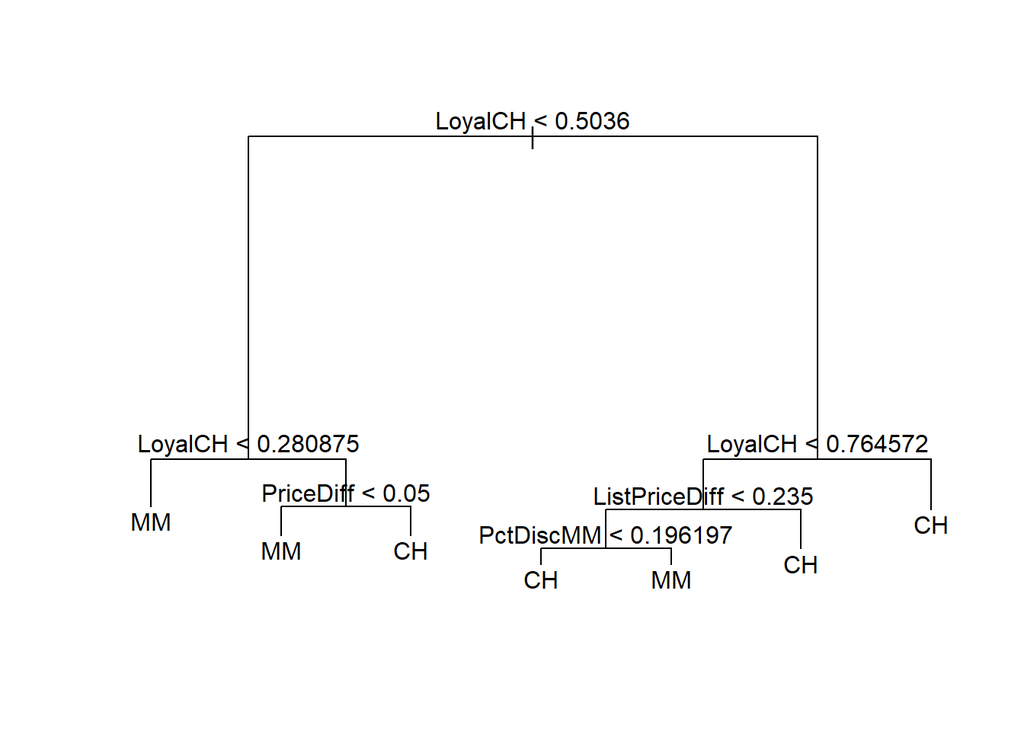

```r
prune.oj <- prune.misclass(tree.oj, best = 7)
plot(prune.oj)
text(prune.oj, pretty = 0)
```

```r
yhat <- predict(prune.oj, tree.train, type = "class")
table(yhat, tree.train$Purchase)
```

```
##
## yhat  CH  MM
##   CH 441  86
##   MM  44 229
```

```r
(44+86)/800 # 16.25% error rate on pruned training
```

```
## [1] 0.1625
```

```r
yhat <- predict(tree.oj, tree.train, type = "class")
table(yhat, tree.train$Purchase)
```

```
##
## yhat  CH  MM
##   CH 450  92
##   MM  35 223
```

```r
(35+92)/800 # 15.88% error rate on the unpruned training
```

```
## [1] 0.15875
```

```r
yhat <- predict(prune.oj, tree.test, type = "class")
table(yhat, tree.test$Purchase)
```

```
##
## yhat  CH  MM
##   CH 160  36
##   MM   8  66
```

```r
(8+36)/270 # 16.30% error rate on pruned test
```

```
## [1] 0.162963
```

```r
yhat <- predict(tree.oj, tree.test, type = "class")
table(yhat, tree.test$Purchase)
```

```
##
## yhat  CH  MM
##   CH 160  38
##   MM   8  64
```

```r
(8+38)/270 # 17.04% error rate on unpruned test
```

```
## [1] 0.1703704
```

## Bagging tree

```r
set.seed(1)
bag.oj <- randomForest(Purchase ~ .,
                       data=tree.train,
                       mtry=17,
                       importance =TRUE)
bag.oj
```

```
##
## Call:
##  randomForest(formula = Purchase ~ ., data = tree.train, mtry = 17,      importance = TRUE)
##                Type of random forest: classification
##                      Number of trees: 500
## No. of variables tried at each split: 17
##
##         OOB estimate of  error rate: 20.38%
## Confusion matrix:
##     CH  MM class.error
## CH 399  86   0.1773196
## MM  77 238   0.2444444
```

```r
yhat <- predict(bag.oj, newdata=tree.test)
table(yhat, tree.test$Purchase)
```

```
##
## yhat  CH  MM
##   CH 152  34
##   MM  16  68
```

```r
(16+34)/270 * 100 # 18.52 test error
```

```
## [1] 18.51852
```

## Boosting

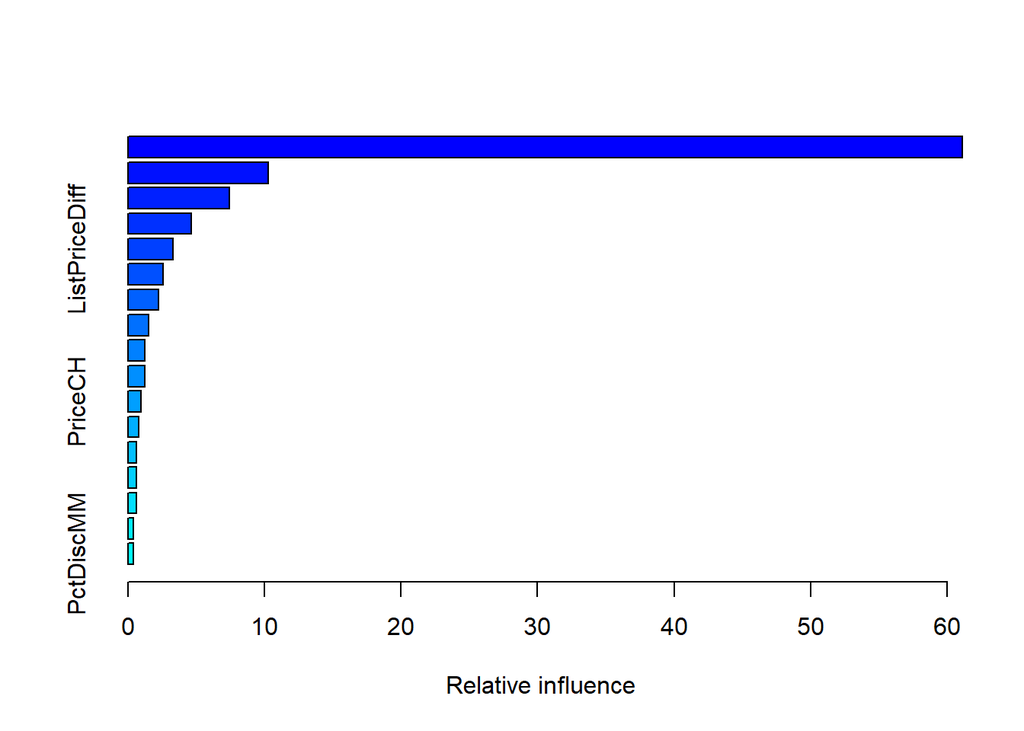

```
##                           var    rel.inf
## LoyalCH               LoyalCH 61.1133749
## PriceDiff           PriceDiff 10.2968256
## WeekofPurchase WeekofPurchase  7.4390296
## StoreID               StoreID  4.6419445
## ListPriceDiff   ListPriceDiff  3.3125061
## SalePriceMM       SalePriceMM  2.5523242
## STORE                   STORE  2.2301344
## SalePriceCH       SalePriceCH  1.5346850
## PriceMM               PriceMM  1.2452581
## SpecialCH           SpecialCH  1.2185141
## PriceCH               PriceCH  0.9273195
## SpecialMM           SpecialMM  0.7847726
## Store7                 Store7  0.6410157
## DiscCH                 DiscCH  0.6193361
## DiscMM                 DiscMM  0.6083691
## PctDiscCH           PctDiscCH  0.4219849
## PctDiscMM           PctDiscMM  0.4126055
```

```r
set.seed(1)
tree.train$Purchase <- as.numeric(tree.train$Purchase)-1
tree.test$Purchase <- as.numeric(tree.test$Purchase)-1
boost.oj <- gbm(
  Purchase ~ .,
  data = tree.train,
  distribution = "bernoulli",
  n.trees = 1000,
  interaction.depth = 4,
  shrinkage = 0.01
)
summary(boost.oj)
```

```r
yhat.boost <- predict(boost.oj, tree.test, n.trees = 1000, type = "response")

yhat.boost <- ifelse(yhat.boost > .50, 1, 0)
table(predicted=yhat.boost, observed =tree.test$Purchase)
```

```
##          observed
## predicted   0   1
##         0 152  30
##         1  16  72
```

```r
(16+30)/270*100 # 17.037% test error rate if you assume 50% is MM
```

```
## [1] 17.03704
```

## Neural network

```r
model <- keras_model_sequential() %>%
  layer_dense(units = 16, activation = "relu", input_shape = dim(nn_train_data)[[2]]) %>%
  layer_dense(units = 16, activation = "relu") %>%
  layer_dense(units = 1, activation = "sigmoid")

model %>% compile(
  optimizer = "rmsprop",
  loss = "binary_crossentropy",
  metrics = c("accuracy")
)

val_indices <- 1:200

x_val <- nn_train_data[val_indices,]
partial_x_train <- nn_train_data[-val_indices,]
y_val <- nn_train_label[val_indices]
partial_y_train <- nn_train_label[-val_indices]

history <- model %>% fit(
  partial_x_train,
  partial_y_train,
  epochs = 20,
  batch_size = 512,
  validation_data = list(x_val, y_val)
)
```

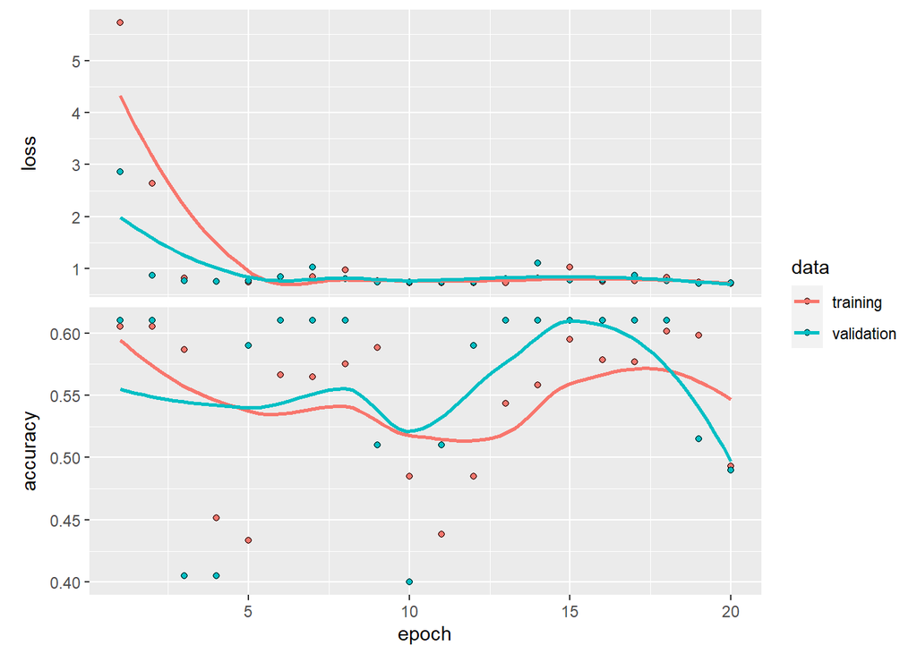

```r
plot(history)
```

## Try 9 epochs

```r
model %>% fit(nn_train_data, nn_train_label, epochs = 9)

results <- model %>% evaluate(nn_test_data, nn_test_label)
results
```

```
##      loss  accuracy
## 0.9105132 0.3777778
```

Current accuracy is significantly worse than the tree methods

```r
# Try other methods
model <- keras_model_sequential() %>%
  layer_dense(units = 8, activation = "relu", input_shape = dim(nn_train_data)[[2]]) %>%
  layer_dense(units = 8, activation = "relu") %>%
  layer_dense(units = 1, activation = "sigmoid")

model %>% compile(
  optimizer = "rmsprop",
  loss = "binary_crossentropy",
  metrics = c("accuracy")
)
model %>% fit(nn_train_data, nn_train_label, epochs = 9)

results <- model %>% evaluate(nn_test_data, nn_test_label)
results
```

```
##      loss  accuracy
## 0.6578387 0.6222222
```

```r
## Remove predictors
nn_data.small <- nn_data[,-c(1,2,13,17)]
nn_train_data <- data.matrix(nn_data.small[train,])
nn_test_data <- data.matrix(nn_data.small[-train,])

# Try other methods
model <- keras_model_sequential() %>%
  layer_dense(units = 8, activation = "relu", input_shape = dim(nn_train_data)[[2]]) %>%
  layer_dense(units = 8, activation = "relu") %>%
  layer_dense(units = 1, activation = "sigmoid")

model %>% compile(
  optimizer = "rmsprop",
  loss = "binary_crossentropy",
  metrics = c("accuracy")
)
model %>% fit(nn_train_data, nn_train_label, epochs = 9)

results <- model %>% evaluate(nn_test_data, nn_test_label)
results
```

```
##      loss  accuracy
## 0.5800470 0.6814815
```

Accuracy increased by removing the predictors

```r
# Try other methods
model <- keras_model_sequential() %>%
  layer_dense(units = 32, activation = "relu", input_shape = dim(nn_train_data)[[2]]) %>%
  layer_dense(units = 16, activation = "relu") %>%
  layer_dense(units = 8, activation = "relu") %>%
  layer_dense(units = 1, activation = "sigmoid")

model %>% compile(
  optimizer = "rmsprop",
  loss = "binary_crossentropy",
  metrics = c("accuracy")
)
model %>% fit(nn_train_data, nn_train_label, epochs = 9)

results <- model %>% evaluate(nn_test_data, nn_test_label)
results
```

```
##      loss  accuracy
## 0.4756361 0.8148148
```

Even better results

```r
# Try other methods
model <- keras_model_sequential() %>%
  layer_dense(units = 32, activation = "relu", input_shape = dim(nn_train_data)[[2]]) %>%
  layer_dense(units = 16, activation = "relu") %>%
  layer_dense(units = 8, activation = "relu") %>%
  layer_dense(units = 1, activation = "sigmoid")

model %>% compile(
  optimizer = "rmsprop",
  loss = "binary_crossentropy",
  metrics = c("accuracy")
)
model %>% fit(nn_train_data, nn_train_label, epochs = 20)

results <- model %>% evaluate(nn_test_data, nn_test_label)
results
```

```
##      loss  accuracy
## 0.3928064 0.8444445
```